# T-DEV-810

## 1. Using Tensorflow

### a. Import the libraries

##### In order to use tensorflow and draw results properly, we will import some libraries.

```python
import os
import numpy as np
import pandas as pd
import random
import matplotlib.pyplot as plt
%matplotlib inline
import keras.backend as K
import cv2
from keras.models import Model, Sequential
from keras.layers import Input, Dense, Flatten, Dropout, BatchNormalization
from keras.layers import Conv2D, SeparableConv2D, MaxPool2D, LeakyReLU, Activation
from keras.optimizers import Adam
from keras.preprocessing.image import ImageDataGenerator
from keras.callbacks import ModelCheckpoint, ReduceLROnPlateau, EarlyStopping
from sklearn.metrics import accuracy_score, confusion_matrix
import tensorflow as tf
```

### b. Display some data

##### Before doing the algorithm, let's diplay some images of our dataset

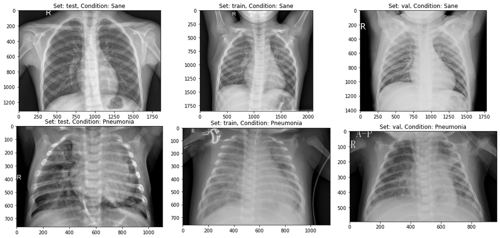

```python
input_path = './chest_Xray/'
dataset_enum = enumerate(['test', 'train', 'val'])

fig, ax = plt.subplots(2, 3, figsize=(15, 7))
ax = ax.ravel()
plt.tight_layout()

for i, _set in dataset_enum:
    set_path = input_path + _set
    ax[i].imshow(plt.imread(set_path + '/NORMAL/' + os.listdir(set_path + '/NORMAL')[0]), cmap='gray')
    ax[i].set_title('Set: {}, Condition: Sane'.format(_set))
    ax[i+3].imshow(plt.imread(set_path + '/PNEUMONIA/' + os.listdir(set_path + '/PNEUMONIA')[0]), cmap='gray')
    ax[i+3].set_title('Set: {}, Condition: Pneumonia'.format(_set))
```

##### We can also see what is the distribution of our images over the 2 categories

```python
for _set in ['test', 'train', 'val']:
    n_normal = len(os.listdir(input_path + _set + '/NORMAL'))
    n_infect = len(os.listdir(input_path + _set + '/PNEUMONIA'))
    print('{} set: normal images = {} | pneumonia images = {}'.format(_set, n_normal, n_infect))
```

```
test set: normal images = 234 | pneumonia images = 390
train set: normal images = 1341 | pneumonia images = 3875
val set: normal images = 8 | pneumonia images = 8
```

### c. Prepare the data

##### All our images aren't the same size so we will need to resize them. We also have to load our images with their label (PNEUMONIA/NORMAL)

```python
def process_data(img_dims, batch_size):
    train_datagen = ImageDataGenerator(rescale=1./255, zoom_range=0.3, vertical_flip=True)
    test_val_datagen = ImageDataGenerator(rescale=1./255)
    train_gen = train_datagen.flow_from_directory(
    directory=input_path + 'train',
    target_size=(img_dims, img_dims),
    batch_size=batch_size,
    class_mode='binary',
    shuffle=True)
    test_gen = test_val_datagen.flow_from_directory(
    directory=input_path + 'test',
    target_size=(img_dims, img_dims),
    batch_size=batch_size,
    class_mode='binary',
    shuffle=True)

    test_data = []
    test_labels = []
    for status in ['/NORMAL/', '/PNEUMONIA/']:
        for img in (os.listdir(input_path + 'test' + status)):
            img = plt.imread(input_path + 'test' + status + img)
            img = cv2.resize(img, (img_dims, img_dims))
            img = np.dstack([img, img, img])
            img = img.astype('float32') / 255
            if status == '/NORMAL/':
                label = 0
            elif status == '/PNEUMONIA/':
                label = 1
            test_data.append(img)
            test_labels.append(label)

    test_data = np.array(test_data)
    test_labels = np.array(test_labels)

    return train_gen, test_gen, test_data, test_labels
```

##### We need to set hyperparameters of our futur CNN.

```python
img_dims = 150
epochs = 50
batch_size = 32
train_gen, test_gen, test_data, test_labels = process_data(img_dims, batch_size)
```

```
Found 5216 images belonging to 2 classes.
Found 624 images belonging to 2 classes.
```

### d. Build the CNN

##### Now we need to build our custom CNN.

```python
# Input layer
inputs = Input(shape=(img_dims, img_dims, 3))

# Convulotion 1
x = Conv2D(filters=16, kernel_size=(3, 3), activation='relu', padding='same')(inputs)
x = Conv2D(filters=16, kernel_size=(3, 3), activation='relu', padding='same')(x)
x = MaxPool2D(pool_size=(2, 2))(x)

# 2
x = SeparableConv2D(filters=32, kernel_size=(3, 3), activation='relu', padding='same')(x)
x = SeparableConv2D(filters=32, kernel_size=(3, 3), activation='relu', padding='same')(x)
x = BatchNormalization()(x)
x = MaxPool2D(pool_size=(2, 2))(x)

# 3
x = SeparableConv2D(filters=64, kernel_size=(3, 3), activation='relu', padding='same')(x)
x = SeparableConv2D(filters=64, kernel_size=(3, 3), activation='relu', padding='same')(x)
x = BatchNormalization()(x)
x = MaxPool2D(pool_size=(2, 2))(x)

# 4
x = SeparableConv2D(filters=128, kernel_size=(3, 3), activation='relu', padding='same')(x)
x = SeparableConv2D(filters=128, kernel_size=(3, 3), activation='relu', padding='same')(x)
x = BatchNormalization()(x)
x = MaxPool2D(pool_size=(2, 2))(x)
x = Dropout(rate=0.2)(x)

# 5
x = SeparableConv2D(filters=256, kernel_size=(3, 3), activation='relu', padding='same')(x)
x = SeparableConv2D(filters=256, kernel_size=(3, 3), activation='relu', padding='same')(x)
x = BatchNormalization()(x)
x = MaxPool2D(pool_size=(2, 2))(x)
x = Dropout(rate=0.2)(x)

x = Flatten()(x)
x = Dense(units=512, activation='relu')(x)
x = Dropout(rate=0.4)(x)
x = Dense(units=128, activation='relu')(x)
x = Dropout(rate=0.5)(x)
x = Dense(units=64, activation='relu')(x)
x = Dropout(rate=0.3)(x)

# Output
output = Dense(units=1, activation='sigmoid')(x)

# Creating model and compiling
model = Model(inputs=inputs, outputs=output)
model.compile(optimizer='adam', loss='binary_crossentropy', metrics=['accuracy'])

# Callbacks
checkpoint = ModelCheckpoint(filepath='best_weights.hdf5', save_best_only=True, save_weights_only=True)
lr_reduce = ReduceLROnPlateau(monitor='val_loss', factor=0.3, patience=2, verbose=2, mode='max')
early_stop = EarlyStopping(monitor='val_loss', min_delta=0.1, patience=1, mode='min')
```

##### Now we wil train our CNN.

```python
hist = model.fit_generator(
           train_gen, steps_per_epoch=train_gen.samples // batch_size,
           epochs=epochs, validation_data=test_gen,
           validation_steps=test_gen.samples // batch_size, callbacks=[checkpoint, lr_reduce])
```

```
Epoch 00005: ReduceLROnPlateau reducing learning rate to 0.0003000000142492354.

Epoch 00007: ReduceLROnPlateau reducing learning rate to 9.000000427477062e-05.

Epoch 00009: ReduceLROnPlateau reducing learning rate to 2.700000040931627e-05.

Epoch 00011: ReduceLROnPlateau reducing learning rate to 8.100000013655517e-06.

Epoch 00013: ReduceLROnPlateau reducing learning rate to 2.429999949526973e-06.

Epoch 00015: ReduceLROnPlateau reducing learning rate to 7.289999985005124e-07.

Epoch 00017: ReduceLROnPlateau reducing learning rate to 2.1870000637136398e-07.

Epoch 00019: ReduceLROnPlateau reducing learning rate to 6.561000276406048e-08.

Epoch 00021: ReduceLROnPlateau reducing learning rate to 1.9683000829218145e-08.

Epoch 00023: ReduceLROnPlateau reducing learning rate to 5.904900035602622e-09.

Epoch 00025: ReduceLROnPlateau reducing learning rate to 1.7714700373261393e-09.

Epoch 00027: ReduceLROnPlateau reducing learning rate to 5.314410245205181e-10.

Epoch 00029: ReduceLROnPlateau reducing learning rate to 1.5943230069481729e-10.

Epoch 00031: ReduceLROnPlateau reducing learning rate to 4.7829690208445185e-11.

Epoch 00033: ReduceLROnPlateau reducing learning rate to 1.434890747886719e-11.

Epoch 00035: ReduceLROnPlateau reducing learning rate to 4.304672243660157e-12.

Epoch 00037: ReduceLROnPlateau reducing learning rate to 1.2914016210563428e-12.

Epoch 00039: ReduceLROnPlateau reducing learning rate to 3.874204993273289e-13.

Epoch 00041: ReduceLROnPlateau reducing learning rate to 1.162261530508052e-13.

Epoch 00043: ReduceLROnPlateau reducing learning rate to 3.4867844288938296e-14.

Epoch 00045: ReduceLROnPlateau reducing learning rate to 1.0460353083393582e-14.

Epoch 00047: ReduceLROnPlateau reducing learning rate to 3.138105874196098e-15.

Epoch 00049: ReduceLROnPlateau reducing learning rate to 9.414317622588293e-16.
```

### e. Test results

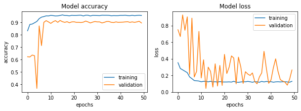

```python
fig, ax = plt.subplots(1, 2, figsize=(10, 3))
ax = ax.ravel()

for i, metric in enumerate(['accuracy', 'loss']):
    ax[i].plot(hist.history[metric])
    ax[i].plot(hist.history['val_' + metric])
    ax[i].set_title('Model {}'.format(metric))
    ax[i].set_xlabel('epochs')
    ax[i].set_ylabel(metric)
    ax[i].legend(['training', 'validation'])
```

##### And finally we can see the rate prediction of our CNN on the test dataset

```python
preds = model.predict(test_data)
acc = accuracy_score(test_labels, np.round(preds)) * 100
cm = confusion_matrix(test_labels, np.round(preds))
tn, fp, fn, tp = cm.ravel()

print('CONFUSION MATRIX')
print(cm)

print('\nTEST METRICS')
precision = tp/(tp+fp)*100
recall = tp/(tp+fn)*100
print('Accuracy: {}%'.format(acc))
print('Precision: {}%'.format(precision))
print('Recall: {}%'.format(recall))
print('F1-score: {}'.format(2 * precision * recall / (precision + recall)))

print('\nTRAIN METRIC')
print('Training accuracy: {}%'.format(np.round((hist.history['accuracy'][-1]) * 100, 2)))
```

```
CONFUSION MATRIX
[[186  48]
 [ 12 378]]

TEST METRICS
Accuracy: 90.38461538461539%
Precision: 88.73239436619718%
Recall: 96.92307692307692%
F1-score: 92.64705882352943

TRAIN METRIC
Training accuracy: 95.55%
```

## 2. Using PyTorch

### a. Import the libraries

```python
import torchvision
from torchvision import transforms, datasets, models
import torch
from torch import optim, cuda
import pandas as pd
from torch.utils.data import DataLoader, sampler
import torch.nn as nn
import numpy as np
from torchsummary import summary
from timeit import default_timer as timer
import os
from PIL import Image
import matplotlib.pyplot as plt
```

### b. Set variables

```python
batch_size = 24
datadir = 'chest_Xray'
train_dir = datadir + '/train/'
test_dir = datadir + '/test/'
val_dir = datadir + '/val/'
save_file_name = 'vgg16-chest.pt'
checkpoint_path = 'vgg16-chest.pth'
categories = []
img_categories = []
n_train = []
n_valid = []
n_test = []
hs = []
ws = []
```

### c. Choose between CPU and GPU for training

```python
train_on_gpu = cuda.is_available()
if train_on_gpu:
    gpu_count = cuda.device_count()
    print(f'{gpu_count} gpus detected.')
    if gpu_count > 1:
        multi_gpu = True
    else:
        multi_gpu = False
```

```
1 gpus detected.
```

### d. Load the datasets

```python
for categorie in os.listdir(train_dir):
    categories.append(categorie)
    train_imgs = os.listdir(train_dir + categorie)
    valid_imgs = os.listdir(val_dir + categorie)
    test_imgs = os.listdir(test_dir + categorie)
    n_train.append(len(train_imgs))
    n_valid.append(len(valid_imgs))
    n_test.append(len(test_imgs))
    for image in train_imgs:
        img_categories.append(image)
        img = Image.open(train_dir + categorie + '/' + image)
        img_array = np.array(img)
        hs.append(img_array.shape[0])
        ws.append(img_array.shape[1])
cat_df = pd.DataFrame({'category': categories,
                       'n_train': n_train,
                       'n_valid': n_valid, 'n_test': n_test}).sort_values('category')
image_df = pd.DataFrame({
    'category': img_categories,
    'height': hs,
    'width': ws
})
n_classes = len(cat_df)
```

### e. Display the data distribution

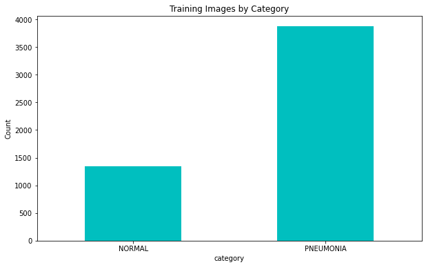

```python
cat_df.set_index('category')['n_train'].plot.bar(
    color='c', figsize=(10, 6))
plt.xticks(rotation=0)
plt.ylabel('Count')
plt.title('Training Images by Category')
```

### f. Prepare the data

##### Here we will do data augmentation on our training images (Rotation/Flip/...) and normalize all images to the Imagenet standard

```python
image_transforms = {
    # Train uses data augmentation
    'train':
    transforms.Compose([
        transforms.RandomResizedCrop(size=256, scale=(0.8, 1.0)),
        transforms.RandomRotation(degrees=15),
        transforms.ColorJitter(),
        transforms.RandomHorizontalFlip(),
        transforms.CenterCrop(size=224),
        transforms.ToTensor(),
        transforms.Normalize([0.485, 0.456, 0.406],
                             [0.229, 0.224, 0.225])
    ]),
    # Validation does not use augmentation
    'val':
    transforms.Compose([
        transforms.Resize(size=256),
        transforms.CenterCrop(size=224),
        transforms.ToTensor(),
        transforms.Normalize([0.485, 0.456, 0.406], [0.229, 0.224, 0.225])
    ]),
    # Test does not use augmentation
    'test':
    transforms.Compose([
        transforms.Resize(size=256),
        transforms.CenterCrop(size=224),
        transforms.ToTensor(),
        transforms.Normalize([0.485, 0.456, 0.406], [0.229, 0.224, 0.225])
    ]),
}
```

```python
data = {
    'train':
    datasets.ImageFolder(root=train_dir, transform=image_transforms['train']),
    'val':
    datasets.ImageFolder(root=val_dir, transform=image_transforms['val']),
    'test':
    datasets.ImageFolder(root=test_dir, transform=image_transforms['test'])
}
```

```python
dataloaders = {
    'train': DataLoader(data['train'], batch_size=batch_size, shuffle=True),
    'val': DataLoader(data['val'], batch_size=batch_size, shuffle=True),
    'test': DataLoader(data['test'], batch_size=batch_size, shuffle=True)
}
```

### g. Building the CNN

##### For this algorithm we decided to base our work on the vgg16 model. It's a public pretrain model specialize in the image recognition on which we will add an additional layer.

```python
def get_pretrained_model(model_name):
    """Retrieve a pre-trained model from torchvision

    Params
    -------
        model_name (str): name of the model (currently only accepts vgg16 and resnet50)

    Return
    --------
        model (PyTorch model): cnn

    """

    if model_name == 'vgg16':
        model = models.vgg16(pretrained=True)

        # Freeze early layers
        for param in model.parameters():
            param.requires_grad = False
        n_inputs = model.classifier[6].in_features

        # Add our custom layers
        model.classifier[6] = nn.Sequential(
            nn.Linear(n_inputs, 256), nn.ReLU(), nn.Dropout(0.2),
            nn.Linear(256, n_classes), nn.LogSoftmax(dim=1))

    elif model_name == 'resnet50':
        model = models.resnet50(pretrained=True)

        for param in model.parameters():
            param.requires_grad = False

        n_inputs = model.fc.in_features
        model.fc = nn.Sequential(
            nn.Linear(n_inputs, 256), nn.ReLU(), nn.Dropout(0.2),
            nn.Linear(256, n_classes), nn.LogSoftmax(dim=1))

    if train_on_gpu:
        model = model.to('cuda')

    if multi_gpu:
        model = nn.DataParallel(model)

    return model
```

```python
model = get_pretrained_model('vgg16')
if multi_gpu:
    summary(
        model.module,
        input_size=(3, 224, 224),
        batch_size=batch_size,
        device='cuda')
else:
    summary(
        model, input_size=(3, 224, 224), batch_size=batch_size, device='cuda')
```

```
----------------------------------------------------------------
        Layer (type)               Output Shape         Param #
================================================================
            Conv2d-1         [24, 64, 224, 224]           1,792
              ReLU-2         [24, 64, 224, 224]               0
            Conv2d-3         [24, 64, 224, 224]          36,928
              ReLU-4         [24, 64, 224, 224]               0
         MaxPool2d-5         [24, 64, 112, 112]               0
            Conv2d-6        [24, 128, 112, 112]          73,856
              ReLU-7        [24, 128, 112, 112]               0
            Conv2d-8        [24, 128, 112, 112]         147,584
              ReLU-9        [24, 128, 112, 112]               0
        MaxPool2d-10          [24, 128, 56, 56]               0
           Conv2d-11          [24, 256, 56, 56]         295,168
             ReLU-12          [24, 256, 56, 56]               0
           Conv2d-13          [24, 256, 56, 56]         590,080
             ReLU-14          [24, 256, 56, 56]               0
           Conv2d-15          [24, 256, 56, 56]         590,080
             ReLU-16          [24, 256, 56, 56]               0
        MaxPool2d-17          [24, 256, 28, 28]               0
           Conv2d-18          [24, 512, 28, 28]       1,180,160
             ReLU-19          [24, 512, 28, 28]               0
           Conv2d-20          [24, 512, 28, 28]       2,359,808
             ReLU-21          [24, 512, 28, 28]               0
           Conv2d-22          [24, 512, 28, 28]       2,359,808
             ReLU-23          [24, 512, 28, 28]               0
        MaxPool2d-24          [24, 512, 14, 14]               0
           Conv2d-25          [24, 512, 14, 14]       2,359,808
             ReLU-26          [24, 512, 14, 14]               0
           Conv2d-27          [24, 512, 14, 14]       2,359,808
             ReLU-28          [24, 512, 14, 14]               0
           Conv2d-29          [24, 512, 14, 14]       2,359,808
             ReLU-30          [24, 512, 14, 14]               0
        MaxPool2d-31            [24, 512, 7, 7]               0
AdaptiveAvgPool2d-32            [24, 512, 7, 7]               0
           Linear-33                 [24, 4096]     102,764,544
             ReLU-34                 [24, 4096]               0
          Dropout-35                 [24, 4096]               0
           Linear-36                 [24, 4096]      16,781,312
             ReLU-37                 [24, 4096]               0
          Dropout-38                 [24, 4096]               0
           Linear-39                  [24, 256]       1,048,832
             ReLU-40                  [24, 256]               0
          Dropout-41                  [24, 256]               0
           Linear-42                    [24, 2]             514
       LogSoftmax-43                    [24, 2]               0
================================================================
Total params: 135,309,890
Trainable params: 1,049,346
Non-trainable params: 134,260,544
----------------------------------------------------------------
Input size (MB): 13.78
Forward/backward pass size (MB): 5250.70
Params size (MB): 516.17
Estimated Total Size (MB): 5780.65
----------------------------------------------------------------
```

```python
trainiter = iter(dataloaders['train'])
features, labels = next(trainiter)
features.shape, labels.shape
model.class_to_idx = data['train'].class_to_idx
model.idx_to_class = {
    idx: class_
    for class_, idx in model.class_to_idx.items()
}

list(model.idx_to_class.items())
```

```
[(0, 'NORMAL'), (1, 'PNEUMONIA')]
```

##### Now we need to write the function that will train our model on our dataset

##### We will also define a load and save function. Thanks to them we will be allowed to re-use our model without re-running it

```python
def train(model,
          criterion,
          optimizer,
          train_loader,
          valid_loader,
          save_file_name,
          max_epochs_stop=3,
          n_epochs=20,
          print_every=2):
    """Train a PyTorch Model

    Params
    --------
        model (PyTorch model): cnn to train
        criterion (PyTorch loss): objective to minimize
        optimizer (PyTorch optimizier): optimizer to compute gradients of model parameters
        train_loader (PyTorch dataloader): training dataloader to iterate through
        valid_loader (PyTorch dataloader): validation dataloader used for early stopping
        save_file_name (str ending in '.pt'): file path to save the model state dict
        max_epochs_stop (int): maximum number of epochs with no improvement in validation loss for early stopping
        n_epochs (int): maximum number of training epochs
        print_every (int): frequency of epochs to print training stats

    Returns
    --------
        model (PyTorch model): trained cnn with best weights
        history (DataFrame): history of train and validation loss and accuracy
    """
    epochs_no_improve = 0
    valid_loss_min = np.Inf

    valid_max_acc = 0
    history = []
    try:
        print(f'Model has been trained for: {model.epochs} epochs.\n')
    except:
        model.epochs = 0
        print(f'Starting Training from Scratch.\n')

    overall_start = timer()

    # Main loop
    for epoch in range(n_epochs):

        # keep track of training and validation loss each epoch
        train_loss = 0.0
        valid_loss = 0.0

        train_acc = 0
        valid_acc = 0

        # Set to training
        model.train()
        start = timer()

        # Training loop
        for ii, (data, target) in enumerate(train_loader):
            # Tensors to gpu
            if train_on_gpu:
                data, target = data.cuda(), target.cuda()

            # Clear gradients
            optimizer.zero_grad()
            # Predicted outputs are log probabilities
            output = model(data)

            # Loss and backpropagation of gradients
            loss = criterion(output, target)
            loss.backward()

            # Update the parameters
            optimizer.step()

            # Track train loss by multiplying average loss by number of examples in batch
            train_loss += loss.item() * data.size(0)

            # Calculate accuracy by finding max log probability
            _, pred = torch.max(output, dim=1)
            correct_tensor = pred.eq(target.data.view_as(pred))
            correct = np.squeeze(correct_tensor.numpy()) if not train_on_gpu else np.squeeze(correct_tensor.cpu().numpy())
            # calculate test accuracy for each object class
            '''for i in range(batch_size):
                label = target.data[i]
                class_correct[label] += correct[i].item()
                class_total[label] += 1'''

            accuracy = torch.mean(correct_tensor.type(torch.FloatTensor))
            train_acc += accuracy.item() * data.size(0)

            # Track training progress
            print(
                f'Epoch: {epoch}\t{100 * (ii + 1) / len(train_loader):.2f}% complete. {timer() - start:.2f} seconds elapsed in epoch.',
                end='\r')

        # After training loops ends, start validation
        else:
            model.epochs += 1
            with torch.no_grad():
                model.eval()

                for data, target in valid_loader:
                    if train_on_gpu:
                        data, target = data.cuda(), target.cuda()

                    output = model(data)

                    loss = criterion(output, target)
                    valid_loss += loss.item() * data.size(0)

                    _, pred = torch.max(output, dim=1)
                    correct_tensor = pred.eq(target.data.view_as(pred))
                    accuracy = torch.mean(
                        correct_tensor.type(torch.FloatTensor))
                    valid_acc += accuracy.item() * data.size(0)

                train_loss = train_loss / len(train_loader.dataset)
                valid_loss = valid_loss / len(valid_loader.dataset)

                train_acc = train_acc / len(train_loader.dataset)
                valid_acc = valid_acc / len(valid_loader.dataset)

                history.append([train_loss, valid_loss, train_acc, valid_acc])

                # Print training and validation results
                if (epoch + 1) % print_every == 0:
                    print(
                        f'\nEpoch: {epoch} \tTraining Loss: {train_loss:.4f} \tValidation Loss: {valid_loss:.4f}'
                    )
                    print(
                        f'\t\tTraining Accuracy: {100 * train_acc:.2f}%\t Validation Accuracy: {100 * valid_acc:.2f}%'
                    )

                if valid_loss < valid_loss_min:
                    torch.save(model.state_dict(), save_file_name)
                    epochs_no_improve = 0
                    valid_loss_min = valid_loss
                    valid_best_acc = valid_acc
                    best_epoch = epoch

                else:
                    epochs_no_improve += 1
                    if epochs_no_improve >= max_epochs_stop:
                        print(
                            f'\nEarly Stopping! Total epochs: {epoch}. Best epoch: {best_epoch} with loss: {valid_loss_min:.2f} and acc: {100 * valid_acc:.2f}%'
                        )
                        total_time = timer() - overall_start
                        print(
                            f'{total_time:.2f} total seconds elapsed. {total_time / (epoch+1):.2f} seconds per epoch.'
                        )

                        model.load_state_dict(torch.load(save_file_name))
                        # Attach the optimizer
                        model.optimizer = optimizer

                        history = pd.DataFrame(
                            history,
                            columns=[
                                'train_loss', 'valid_loss', 'train_acc',
                                'valid_acc'
                            ])
                        return model, history

    model.optimizer = optimizer
    total_time = timer() - overall_start
    print(
        f'\nBest epoch: {best_epoch} with loss: {valid_loss_min:.2f} and acc: {100 * valid_acc:.2f}%'
    )
    print(
        f'{total_time:.2f} total seconds elapsed. {total_time / (epoch):.2f} seconds per epoch.'
    )
    # Format history
    history = pd.DataFrame(
        history,
        columns=['train_loss', 'valid_loss', 'train_acc', 'valid_acc'])
    return model, history
```

```python
def save_checkpoint(model, path):
    """Save a PyTorch model checkpoint

    Params
    --------
        model (PyTorch model): model to save
        path (str): location to save model. Must start with `model_name-` and end in '.pth'

    Returns
    --------
        None, save the `model` to `path`

    """

    model_name = path.split('-')[0]
    assert (model_name in ['vgg16', 'resnet50'
                           ]), "Path must have the correct model name"

    # Basic details
    checkpoint = {
        'class_to_idx': model.class_to_idx,
        'idx_to_class': model.idx_to_class,
        'epochs': model.epochs,
    }

    if model_name == 'vgg16':
        if multi_gpu:
            checkpoint['classifier'] = model.module.classifier
            checkpoint['state_dict'] = model.module.state_dict()
        else:
            checkpoint['classifier'] = model.classifier
            checkpoint['state_dict'] = model.state_dict()

    elif model_name == 'resnet50':
        if multi_gpu:
            checkpoint['fc'] = model.module.fc
            checkpoint['state_dict'] = model.module.state_dict()
        else:
            checkpoint['fc'] = model.fc
            checkpoint['state_dict'] = model.state_dict()

    # Add the optimizer
    checkpoint['optimizer'] = model.optimizer
    checkpoint['optimizer_state_dict'] = model.optimizer.state_dict()

    # Save the data to the path
    torch.save(checkpoint, path)
```

```python
def load_checkpoint(path):
    """Load a PyTorch model checkpoint

    Params
    --------
        path (str): saved model checkpoint. Must start with `model_name-` and end in '.pth'

    Returns
    --------
        None, save the `model` to `path`

    """

    # Get the model name
    model_name = path.split('-')[0]
    assert (model_name in ['vgg16', 'resnet50'
                           ]), "Path must have the correct model name"

    # Load in checkpoint
    checkpoint = torch.load(path)

    if model_name == 'vgg16':
        model = models.vgg16(pretrained=True)
        # Make sure to set parameters as not trainable
        for param in model.parameters():
            param.requires_grad = False
        model.classifier = checkpoint['classifier']

    elif model_name == 'resnet50':
        model = models.resnet50(pretrained=True)
        # Make sure to set parameters as not trainable
        for param in model.parameters():
            param.requires_grad = False
        model.fc = checkpoint['fc']

    # Load in the state dict
    model.load_state_dict(checkpoint['state_dict'])

    total_params = sum(p.numel() for p in model.parameters())
    print(f'{total_params:,} total parameters.')
    total_trainable_params = sum(
        p.numel() for p in model.parameters() if p.requires_grad)
    print(f'{total_trainable_params:,} total gradient parameters.')

    # Move to gpu
    if multi_gpu:
        model = nn.DataParallel(model)

    if train_on_gpu:
        model = model.to('cuda')

    # Model basics
    model.class_to_idx = checkpoint['class_to_idx']
    model.idx_to_class = checkpoint['idx_to_class']
    model.epochs = checkpoint['epochs']

    # Optimizer
    optimizer = checkpoint['optimizer']
    optimizer.load_state_dict(checkpoint['optimizer_state_dict'])

    return model, optimizer
```

### h. Training the CNN

```python
criterion = nn.NLLLoss()
optimizer = optim.Adam(model.parameters())
model, history = train(
    model,
    criterion,
    optimizer,
    dataloaders['train'],
    dataloaders['val'],
    save_file_name=save_file_name,
    max_epochs_stop=100,
    n_epochs=50,
    print_every=3)
```

```
Starting Training from Scratch.

Epoch: 2	100.00% complete. 110.75 seconds elapsed in epoch.
Epoch: 2 	Training Loss: 0.2231 	Validation Loss: 0.6428
		Training Accuracy: 90.99%	 Validation Accuracy: 62.50%
Epoch: 5	100.00% complete. 108.93 seconds elapsed in epoch.
Epoch: 5 	Training Loss: 0.2089 	Validation Loss: 0.4915
		Training Accuracy: 91.28%	 Validation Accuracy: 68.75%
Epoch: 8	100.00% complete. 108.72 seconds elapsed in epoch.
Epoch: 8 	Training Loss: 0.2136 	Validation Loss: 0.3063
		Training Accuracy: 91.74%	 Validation Accuracy: 81.25%
Epoch: 11	100.00% complete. 108.14 seconds elapsed in epoch.
Epoch: 11 	Training Loss: 0.2135 	Validation Loss: 0.6381
		Training Accuracy: 91.05%	 Validation Accuracy: 62.50%
Epoch: 14	100.00% complete. 108.19 seconds elapsed in epoch.
Epoch: 14 	Training Loss: 0.2038 	Validation Loss: 0.2699
		Training Accuracy: 91.78%	 Validation Accuracy: 93.75%
Epoch: 17	100.00% complete. 110.60 seconds elapsed in epoch.
Epoch: 17 	Training Loss: 0.2042 	Validation Loss: 0.4149
		Training Accuracy: 91.51%	 Validation Accuracy: 81.25%
Epoch: 20	100.00% complete. 108.38 seconds elapsed in epoch.
Epoch: 20 	Training Loss: 0.1968 	Validation Loss: 0.1677
		Training Accuracy: 91.81%	 Validation Accuracy: 100.00%
Epoch: 23	100.00% complete. 109.27 seconds elapsed in epoch.
Epoch: 23 	Training Loss: 0.2056 	Validation Loss: 0.3388
		Training Accuracy: 91.56%	 Validation Accuracy: 81.25%
Epoch: 26	100.00% complete. 111.07 seconds elapsed in epoch.
Epoch: 26 	Training Loss: 0.1929 	Validation Loss: 0.3963
		Training Accuracy: 92.12%	 Validation Accuracy: 81.25%
Epoch: 29	100.00% complete. 111.33 seconds elapsed in epoch.
Epoch: 29 	Training Loss: 0.1824 	Validation Loss: 0.4300
		Training Accuracy: 92.16%	 Validation Accuracy: 81.25%
Epoch: 32	100.00% complete. 108.34 seconds elapsed in epoch.
Epoch: 32 	Training Loss: 0.1889 	Validation Loss: 0.3492
		Training Accuracy: 92.66%	 Validation Accuracy: 81.25%
Epoch: 35	100.00% complete. 111.64 seconds elapsed in epoch.
Epoch: 35 	Training Loss: 0.1921 	Validation Loss: 0.3283
		Training Accuracy: 92.24%	 Validation Accuracy: 81.25%
Epoch: 38	100.00% complete. 111.58 seconds elapsed in epoch.
Epoch: 38 	Training Loss: 0.1948 	Validation Loss: 0.3234
		Training Accuracy: 91.78%	 Validation Accuracy: 81.25%
Epoch: 41	100.00% complete. 112.27 seconds elapsed in epoch.
Epoch: 41 	Training Loss: 0.1797 	Validation Loss: 0.3625
		Training Accuracy: 92.81%	 Validation Accuracy: 81.25%
Epoch: 44	100.00% complete. 113.42 seconds elapsed in epoch.
Epoch: 44 	Training Loss: 0.1849 	Validation Loss: 0.2929
		Training Accuracy: 92.35%	 Validation Accuracy: 81.25%
Epoch: 47	100.00% complete. 114.37 seconds elapsed in epoch.
Epoch: 47 	Training Loss: 0.1828 	Validation Loss: 0.2453
		Training Accuracy: 92.54%	 Validation Accuracy: 87.50%
Epoch: 49	100.00% complete. 112.04 seconds elapsed in epoch.
Best epoch: 20 with loss: 0.17 and acc: 81.25%
5558.40 total seconds elapsed. 113.44 seconds per epoch.
```

### i. Result

###### We can now check the performance of our model

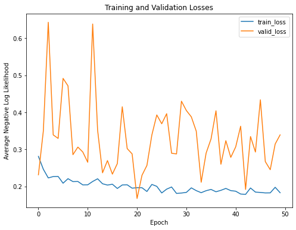

```python
plt.figure(figsize=(8, 6))
for c in ['train_loss', 'valid_loss']:
    plt.plot(history[c], label=c)
plt.legend()
plt.xlabel('Epoch')
plt.ylabel('Average Negative Log Likelihood')
plt.title('Training and Validation Losses')
```

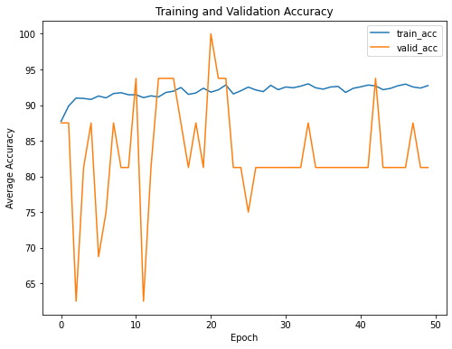

```python
plt.figure(figsize=(8, 6))
for c in ['train_acc', 'valid_acc']:
    plt.plot(
        100 * history[c], label=c)
plt.legend()
plt.xlabel('Epoch')
plt.ylabel('Average Accuracy')
plt.title('Training and Validation Accuracy')
```

###### On those graphs we can see that our model seems to be pretty good on the training and validation dataset

###### Finally we can test our model on our test dataset

```python
test_loader=dataloaders['test']
test_loss = 0.0
class_correct = list(0. for i in range(2))
class_total = list(0. for i in range(2))
classes = [0,1]
model.eval()
i=1
# iterate over test data
len(test_loader)
for data, target in test_loader:
    i=i+1
    if len(target)!=batch_size:
        continue

    # move tensors to GPU if CUDA is available
    if train_on_gpu:
        data, target = data.cuda(), target.cuda()
    # forward pass: compute predicted outputs by passing inputs to the model
    output = model(data)
    # calculate the batch loss
    loss = criterion(output, target)
    # update test loss
    test_loss += loss.item()*data.size(0)
    # convert output probabilities to predicted class
    _, pred = torch.max(output, 1)
    # compare predictions to true label
    correct_tensor = pred.eq(target.data.view_as(pred))
    correct = np.squeeze(correct_tensor.numpy()) if not train_on_gpu else np.squeeze(correct_tensor.cpu().numpy())

    for i in range(batch_size):
        label = target.data[i]
        class_correct[label] += correct[i].item()
        class_total[label] += 1

test_loss = test_loss/len(test_loader.dataset)
print('Test Loss: {:.6f}\n'.format(test_loss))

for i in range(2):
    if class_total[i] > 0:
        print('Test Accuracy of %5s: %2d%% (%2d/%2d)' % (
            classes[i], 100 * class_correct[i] / class_total[i],
            np.sum(class_correct[i]), np.sum(class_total[i])))
    else:
        print('Test Accuracy of %5s: N/A (no training examples)' % (classes[i]))

print('\nTest Accuracy (Overall): %2d%% (%2d/%2d)' % (
    100. * np.sum(class_correct) / np.sum(class_total),
    np.sum(class_correct), np.sum(class_total)))
```

```
Test Loss: 0.533026

Test Accuracy of     0: 60% (141/234)
Test Accuracy of     1: 96% (377/390)

Test Accuracy (Overall): 83% (518/624)
```

##### Here we can see that our model is doing pretty well with 83% of good prediction. It can also help medical services to detect pneumonia